### Introduction

For my first post here, I wanted to delve into the math behind advantage/disadvantage rolls in d20-based table top RPG systems. For a quick reminder, in a d20 system, a player who wants their character to do an action (e.g., attack a foe, find food in the wilderness, or avoid the worst effects of a spell) rolls a 20-sided die (d20), adds relevant modifiers, and compares the result to whatever number defines success in their specific case (e.g., the armor class of the foe or the difficulty level of the feat). In certain circumstances, a character may have an increased or decreased chance of success, reflected by rolling with either advantage or disadvantage, respectively. In these cases, the player rolls two d20’s and keeps either the higher roll (advantage) or lower roll (disadvantage).

A rule of thumb that I’ve heard used is that advantage is roughly a +5 bonus to your roll, while disadvantage is a -5 penalty. I wanted to explore, first, whether this was generally true, and second, how advantage/disadvantage affects what many players really care about, expected damage from their attacks. Also just to note going forward, instead of writing advantage/disadvantage or some longer form, I will just refer to them together as “(dis)advantage”.

### (Dis)advantage and the d20 result

First, let’s take a look simply at how (dis)advantage affects the outcome of the d20 rolls. With a single fair die, it’s a straightforward calculation to know we should expect each number to come 1/20th (or 5%) of the time. When we introduce a second d20, we’re now looking at chances out of 400 (20 $\times$ 20). For advantage, we see we’ve significantly increased our chances of getting higher rolls. Rather than each number having a 5% chance, the chance of a given roll ( $P(r)$ ) follows the following formulas:

$$\begin{aligned}
\text{advantage:} && P(r) &= \frac{2r - 1}{400} \\
\text{disadvantage:} && P(r) &= \frac{41 - 2r}{400}
\end{aligned}$$
Using the first formula, we can see the chance of rolling an 18 is $\frac{2\times18-1}{400} = \frac{35}{400} = 0.0875$. Which is 3.75% higher than for a straight roll. Conversely, for disadvantage we get $\frac{41-2\times18}{400} = \frac{5}{400} = 0.0125$, or a 3.75% reduction in chance compared to a straight roll. So let’s take a look at how (dis)advantage affects the d20 roll distribution in general.

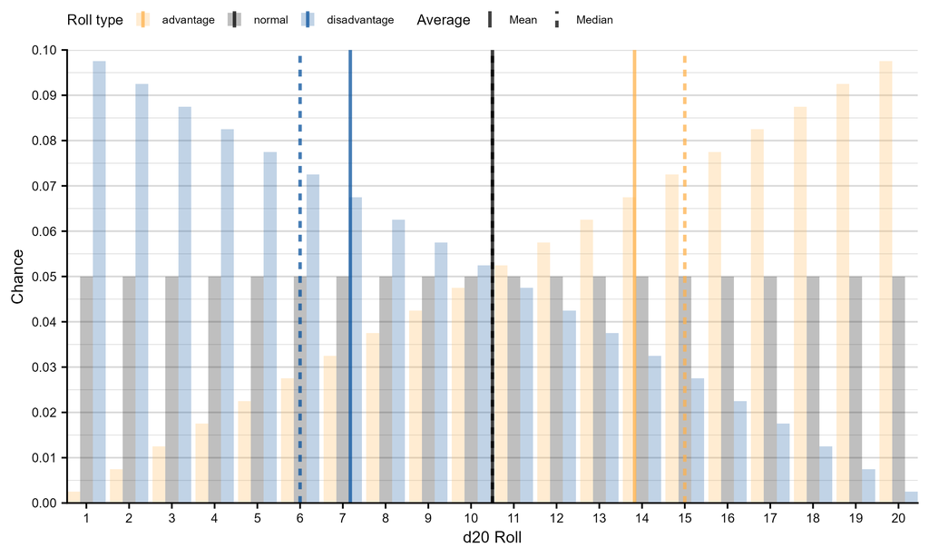

> Figure 1. Chance of raw d20 result based on rolling with advantage (yellow), normally (black), or with disadvantage (blue). Solid lines indicate means and dashed lines indicate medians.

Looking at average results, we can see that both the mean and median of normal rolls are at 10.5. However, the means for (dis)advantage are much less than ±5 from that. In fact, they are only ±3.325 from the normal mean. The medians are further out, sitting at ±4.5 from the normal median.

I wanted to look at this specifically because the rules as written (RAW) for passive checks (where no roll is made, it is simply 10 + the relevant modifiers), adding ±5 for (dis)advantage is quite generous for advantage and quite stingy for disadvantage. It should really be 4 for the sake of whole numbers (and the general rule of rounding down). It’s certainly not a common enough scenario to warrant significant rules changes, but a DM could actually help there players a little by reducing the penalty for disadvantage, especially since passive is already slightly penalized by starting with a round 10, rather than the true mean/median of 10.5.

### The effects of (dis)advantage on damage

One thing this analysis leaves out are the in-game effects of rolling the extremes of the d20: 1 and 20. These rolls, in many d20 systems, result in bigger effects such as critical failures and successes. Here, I’m going to talk primarily in the context of combat, so will focus on how these affect potential damage output and refer to them as a “crit. miss” or “crit. hit”, respectively. For the following examples, I’m going to use a d8 as the damage die, and I’m going to ignore any modifiers to the attack or damage rolls. This should make things more generalizable. For example, by ignoring specific ACs and attack modifiers, we can say what the expected damage should be based on the raw d20 roll target required to hit. So, a character with a +2 attack modifier targeting a foe with a 14 AC and a character with a +4 attack modifier targeting a foe with a 16 AC would need the same d20 target roll: 12. And the expected damage (assuming they’re using the same weapon), would be the same.

To start, I want to show some example distributions of damage output. I’m just going to show the distributions when a successful raw roll is a 5 and a 15, as the full set of graphs is much too complicated. There’s still a lot going on here, but there are a few key takeaways.

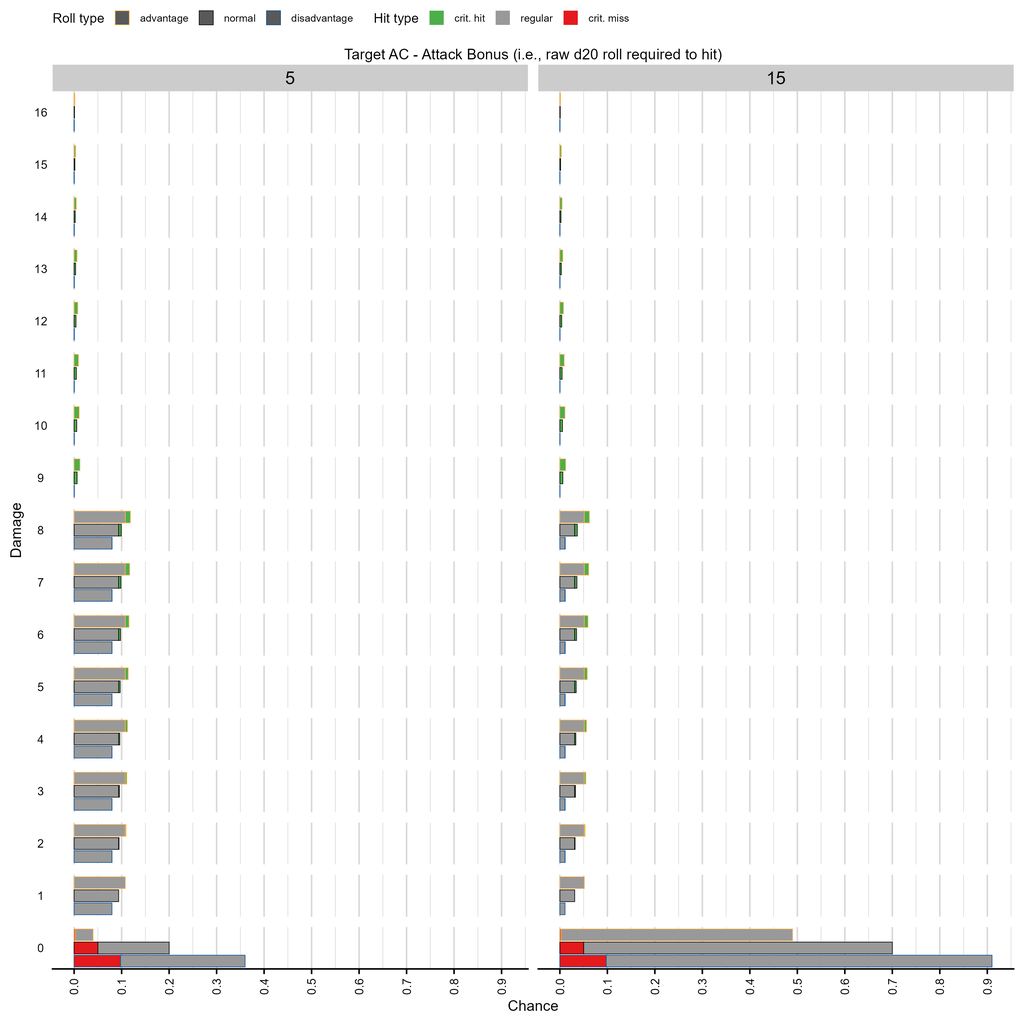

> Figure 2. Examples of damage distributions for two raw d20 roll targets (5 & 15) by roll type (advantage/normal/disadvantage) and hit type (crit. hit/regular/crit. miss) for a character with a weapon that deals 1d8 damage (ability bonus excluded). Expected damage is on the y-axis, and chance to get that damage is on the x-axis.

First, looking at the misses (0 damage), you can see our crit. miss chance is nearly doubled for disadvantage relative to normal rolls, which we expect from figure 1, and this is true regardless of the target for a successful roll. Secondly, the relationship between advantage and disadvantage for chance to miss is not static. When a 5 is all you need to hit, the chance to miss with advantage is 4% while with disadvantage it’s 36%, a difference of 32%. However, when you need a 15 to hit, the chance of missing is 49% with advantage and 91% with disadvantage, a difference of 42%. That’s an appreciably bigger gap.

Let’s simplify things a little bit and just look at the mean expected damage across raw d20 roll targets. I’ve omitted 1 as a target d20 roll because mathematically, it’s identical to 2 (since a 1 is a failure no matter what a player still needs to roll a 2 to hit).

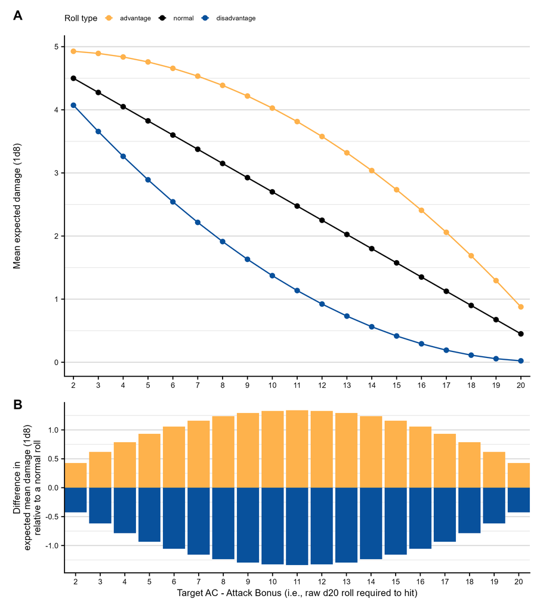

> Figure 3. (A) Mean expected damage for a character with a weapon dealing 1d8 damage (ability bonus excluded) by raw d20 roll and roll type (advantage/normal/disadvantage). (B) Differences in expected mean damage for advantage and disadvantage rolls relative to normal rolls.

As one might expect, for a normal (straight) d20 roll, the expected damage goes down linearly as the required d20 target increases. In fact, it decreases by exactly 5% of the mean dice roll (in this case 5% of 4.5), which makes sense as the chance of hitting the target roll decreases by 5% for each increase of one.

The (dis)advantage rolls, however, do not have a linear relationship with mean expected damage. Rolling with advantage means not only the expected damage is greater than rolling normally, but this increase starts falling off slowly but then accelerates. For disadvantage, it’s the converse. This means that the expected damage gain or loss from (dis)advantage is not static across d20 targets. The lower figure highlights this, showing that the greatest boons from advantage and banes from disadvantage (damage-wise) occur when the target d20 roll is right in the middle (10-12). In this range, the expected damage changes by over ±1.3 points.

For those of use interested in the specific math details, we can generalize beyond d8 damage dice, and determine the mean expected damage output for any die based on the require d20 target to hit as follows:

| Variable | Meaning |
| --- | --- |
| $\overline{D}$ | Mean expected damage from a single attack |
| $\overline{d}$ | Mean damage die roll (e.g., 3.5 for 1d6, 5.5 for 1d10, 7.0 for 2d6) |
| $r$ | raw d20 roll (no modifiers) |

$$\begin{aligned}
\overline{D}_{normal} &= \overline{d} \times \frac{22-r}{20} \\
\overline{D}_{advantage} &= \overline{d} \times \frac{438 + 2r -
r^2}{400} \\
\overline{D}_{disadvantage} &= \overline{d} \times
\frac{442-42r+r^2}{400}
\end{aligned}$$

### Conclusions

I started this particular post because I wanted to have a more complete understanding of how a core mechanic like (dis)advantage actually affects outcomes at the table. It certainly dispelled for me the notion that I can be though of as a static bonus/penalty at all, and highlighted that its effects are variable over d20 targets. Certainly, very few players will need or want to use these formulas at the table, but hopefully this overview can help them make decisions when they can give themselves or compatriots advantage, such as with heroic inspiration or spells like Faerie Fire.